# Simple Python Introduction

### 1. Calculate how much money you would have if you compounded $100 at 10% for 8 years. (Use Python Operators and print the answer to the console).

```python
print(100 * (1.1**8))
```

```
214.35888100000017
```

### 2. Create a variable called “days”. Assign the value “7” to this variable. Try to execute the following code print (“There are ” + days + “ days in a week”). Rewrite the code to avoid the error.

```python
days = 7
```

```python
# Try to execute the following code

print("There are " + days + " days in a week")
```

```
---------------------------------------------------------------------------
TypeError                                 Traceback (most recent call last)
<ipython-input-12-e3b8717b7b7c> in <module>
      1 # Try to execute the following code
      2
----> 3 print("There are " + days + " days in a week")

TypeError: can only concatenate str (not "int") to str
```

```python
# Rewrite the code to avoid the error
print("There are " + str(days) + " days in a week")
```

```
There are 7 days in a week
```

## There are 3 popularly used data types in the Python programming language. These data types let you group items into collections with specific properties (that you can then manipulate further later).

● Lists are a collection which is ordered and changeable. Allows duplicate members. ● Dictionaries are a collection which are unordered, changeable, and indexed. No duplicate members. ● Sets are a collection which is unordered and unindexed. No duplicate members.

### 3. Create a list with the following elements [“Tuesday”, “Wednesday”, “Thursday”, “Friday”, “Saturday”, “Sunday”, 42]. Add the string ‘Someday’ into this list. Add the variable ‘days’ that you previously created into this list. Create a new variable called ‘sliced_list’, which only contain the first 8 elements of the first list. Delete the integer ‘42’ from the list. Change the string ‘Someday’ to ‘Monday’.

```python
list_days = ["Tuesday", "Wednesday", "Thursday", "Friday", "Saturday", "Sunday", 42]
list_days.append("Someday")
list_days.append(days)
```

```python
list_days
```

```
['Tuesday',
 'Wednesday',
 'Thursday',
 'Friday',
 'Saturday',
 'Sunday',
 42,
 'Someday',
 7]
```

```python
# Create a new variable called ‘sliced_list’, which only contain the first 8 elements of the
# first list. Delete the integer ‘42’ from the list. Change the string ‘Someday’ to ‘Monday’

sliced_list = list_days[0:8]
sliced_list.remove(42)
sliced_list[6] = "Monday"
sliced_list
```

```
['Tuesday', 'Wednesday', 'Thursday', 'Friday', 'Saturday', 'Sunday', 'Monday']
```

### 4. Create a dictionary with the following key:value pairs. 'name':['john','mary','peter','jeff','bill','lisa','jose'],

'age':[23,78,22,19,45,33,20], 'gender':['M','F','M','M','M','F','M'], 'State':['california','dc','california','dc','california','texas','texas'], 'num_children':[2,0,0,3,2,1,4]

Add the following key:value pair to the dictionary. 'num_pets':[5,1,0,5,2,2,3]

```python
# Create a dictionary with the following key:value pairs.

dict_person = {
'name':['john','mary','peter','jeff','bill','lisa','jose'],
'age':[23,78,22,19,45,33,20],
'gender':['M','F','M','M','M','F','M'],
'State':['california','dc','california','dc','california','texas','texas'],
'num_children':[2,0,0,3,2,1,4]
}

dict_person
```

```
{'name': ['john', 'mary', 'peter', 'jeff', 'bill', 'lisa', 'jose'],
 'age': [23, 78, 22, 19, 45, 33, 20],
 'gender': ['M', 'F', 'M', 'M', 'M', 'F', 'M'],
 'State': ['california',
  'dc',
  'california',
  'dc',
  'california',
  'texas',
  'texas'],
 'num_children': [2, 0, 0, 3, 2, 1, 4]}
```

```python
# Add the following key:value pair to the dictionary.

dict_person['num_pets'] = [5,1,0,5,2,2,3]

dict_person
```

```
{'name': ['john', 'mary', 'peter', 'jeff', 'bill', 'lisa', 'jose'],
 'age': [23, 78, 22, 19, 45, 33, 20],
 'gender': ['M', 'F', 'M', 'M', 'M', 'F', 'M'],
 'State': ['california',
  'dc',
  'california',
  'dc',
  'california',
  'texas',
  'texas'],
 'num_children': [2, 0, 0, 3, 2, 1, 4],
 'num_pets': [5, 1, 0, 5, 2, 2, 3]}
```

### 5. Import the pandas library as pd and the matplotlib.pylot library as plt. Convert the dictionary above to a dataframe.

```python
# Import the pandas library as pd and the matplotlib.pylot library as plt. Convert the
# dictionary above to a dataframe

import pandas as pd
import matplotlib.pyplot as plt

df = pd.DataFrame(data = dict)
```

```python
df
```

[output not shown]

### 6. Plot a scatterplot of 'num_childern' against 'num_pets'

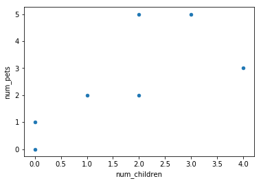

```python
# Plot a scatterplot of 'num_childern' against 'num_pets'

df.plot.scatter('num_children', 'num_pets')
```

### 7. Plot a bar plot of ‘name’ against ‘age’.

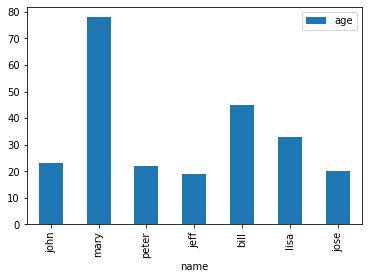

```python
# Plot a bar plot of 'name' against 'age'

df.plot.bar('name', 'age')
```

### 8. Create a list with the numbers 1 to 10. Write a program to loop through the numbers in the list and print “odd” if the number is odd and “even” if the number is even.

```python
list = [1, 2, 3, 4, 5, 6, 7, 8, 9, 10]
```

```python
for number in list:
    if number % 2 == 0:
        print(str(number) + ' is even')
    else:
        print(str(number) + ' is odd')
```

```
1 is odd
2 is even
3 is odd
4 is even
5 is odd
6 is even
7 is odd
8 is even
9 is odd
10 is even
```